# Hoe Portable RStudio installeren

Ludger Goeminne

09/10/2018

## Portable RStudio

Aangezien R en RStudio volledig gratis zijn, moedigen we alle studenten aan om hun eigen laptops te gebruiken, met R en RStudio vooraf geïnstalleerd. Een tweede optie is om gebruik te maken van RStudio via Athena. Een derde optie: een “portable” versie van R en RStudio installeren op een USB-stick of op je netwerk drive (H schijf) van de universiteit.

## Wat is een “portable” applicatie?

Een “portable” applicatie is een applicatie waarvoor de installatiefolder alles bevat dat nodig is om de applicatie uit te voeren. Je hebt dus geen toegang nodig tot beveiligde mappen op de computer en als je de applicatie op een USB-stick installeert, kun je ze overal uitvoeren.

## Hoe Portable RStudio installeren?

Voor het installeren van Portable RStudio moet R worden geïnstalleerd. We zullen dus zowel R Portable als Portable RStudio installeren. Het installeren van beide gaat snel. Dit document neemt de gebruiker bij de hand en leidt hem/haar vlot door het installatieproces.

### 1. R portable installeren

Download de laatste versie van R portable van deze link: https://sourceforge.net/projects/rportable/files/latest/download.

Nadat je R portable hebt gedownload, voer je het installatieprogramma uit.

[figure not shown]

Het installatiescherm zou er als volgt moeten uitzien:

[figure not shown]

**Belangrijk: zorg ervoor dat je R portable installeert op een locatie met schrijfrechten, zoals op je bureaublad of op een verwijderbaar medium zoals een USB-stick of een externe harde schijf.**

[figure not shown]

### 2. Portable RStudio installeren

Download Portable RStudio van: https://sourceforge.net/projects/rportable/files/R-Studio.

**Belangrijk: klik niet op “Download Latest Version” (dit zal R Portable opnieuw downloaden), maar ga naar de map met het nieuwste versienummer (1.1.383 in dit voorbeeld).**

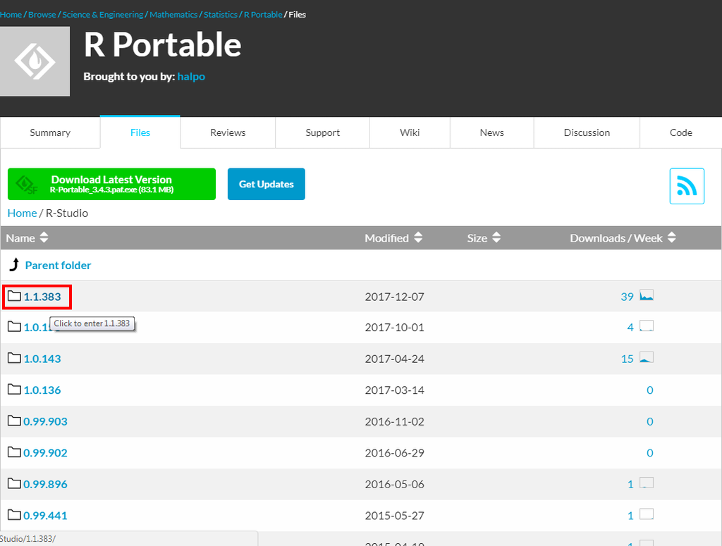

Download in deze submap het bestand dat eindigt op “.paf.exe”.

[figure not shown]

Zorg er opnieuw voor dat Portable RStudio op een locatie met schrijfrechten wordt geïnstalleerd (in ons geval: het bureaublad).

[figure not shown]

### 3. Portable RStudio openen

Om Portable RStudio te openen, open je gewoon de map RStudioPortable die net geïnstalleerd is en dubbelklik je op het bestand “RStudioPortable.exe”.

[figure not shown]

Portable RStudio weet niet waar we onze R Portable hebben opgeslagen, daarom krijg je een venster “Choose R Installation”. Kies de optie “Choose a specific version of R”. Ga in het resulterende venster naar de map **R-Portable** en vervolgens naar “App/R-Portable” en druk op “Select Folder”.

[figure not shown]

Selecteer vervolgens de 64-bits versie van R.

[figure not shown]

RStudio start nu op. Wanneer je je eerste R Markdown-bestand opent, verschijnt het volgende venster:

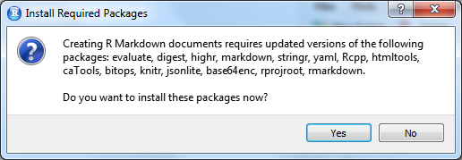

Dit geeft aan dat bepaalde packages nog niet zijn geïnstalleerd. Druk op “Yes” en wacht tot RStudio deze packages installeert. Je kunt nu werken met Portable RStudio.

**Opmerking:** wanneer je Portable RStudio gebruikt, vergeet dan niet om je bestanden op te slaan op je “H:/” -schijf, zodat je later toegang hebt tot je bestanden!